# DATA606_w7: Inference for numerical data

David Simbandumwe

## Getting Started

### Load packages

In this lab, we will explore and visualize the data using the **tidyverse** suite of packages, and perform statistical inference using **infer**. The data can be found in the companion package for OpenIntro resources, **openintro**.

Let’s load the packages.

```r
library(tidyverse)
library(openintro)
library(infer)
library(ggplot2)
```

### The data

Every two years, the Centers for Disease Control and Prevention conduct the Youth Risk Behavior Surveillance System (YRBSS) survey, where it takes data from high schoolers (9th through 12th grade), to analyze health patterns. You will work with a selected group of variables from a random sample of observations during one of the years the YRBSS was conducted.

Load the `yrbss` data set into your workspace.

```r
data('yrbss', package='openintro')
```

There are observations on 13 different variables, some categorical and some numerical. The meaning of each variable can be found by bringing up the help file:

```r
?yrbss
```

1. What are the cases in this data set? How many cases are there in our sample?
- **individual student**
- **13,583 cases and 13 variables**

Remember that you can answer this question by viewing the data in the data viewer or by using the following command:

```r
glimpse(yrbss)
```

```
## Rows: 13,583
## Columns: 13
## $ age                      <int> 14, 14, 15, 15, 15, 15, 15, 14, 15, 15, 15, 1…
## $ gender                   <chr> "female", "female", "female", "female", "fema…
## $ grade                    <chr> "9", "9", "9", "9", "9", "9", "9", "9", "9", …
## $ hispanic                 <chr> "not", "not", "hispanic", "not", "not", "not"…
## $ race                     <chr> "Black or African American", "Black or Africa…
## $ height                   <dbl> NA, NA, 1.73, 1.60, 1.50, 1.57, 1.65, 1.88, 1…
## $ weight                   <dbl> NA, NA, 84.37, 55.79, 46.72, 67.13, 131.54, 7…
## $ helmet_12m               <chr> "never", "never", "never", "never", "did not …
## $ text_while_driving_30d   <chr> "0", NA, "30", "0", "did not drive", "did not…
## $ physically_active_7d     <int> 4, 2, 7, 0, 2, 1, 4, 4, 5, 0, 0, 0, 4, 7, 7, …
## $ hours_tv_per_school_day  <chr> "5+", "5+", "5+", "2", "3", "5+", "5+", "5+",…
## $ strength_training_7d     <int> 0, 0, 0, 0, 1, 0, 2, 0, 3, 0, 3, 0, 0, 7, 7, …
## $ school_night_hours_sleep <chr> "8", "6", "<5", "6", "9", "8", "9", "6", "<5"…
```

## Exploratory data analysis

You will first start with analyzing the weight of the participants in kilograms: `weight`.

```r
summary(yrbss$weight)
```

```
##    Min. 1st Qu.  Median    Mean 3rd Qu.    Max.    NA's
##   29.94   56.25   64.41   67.91   76.20  180.99    1004
```

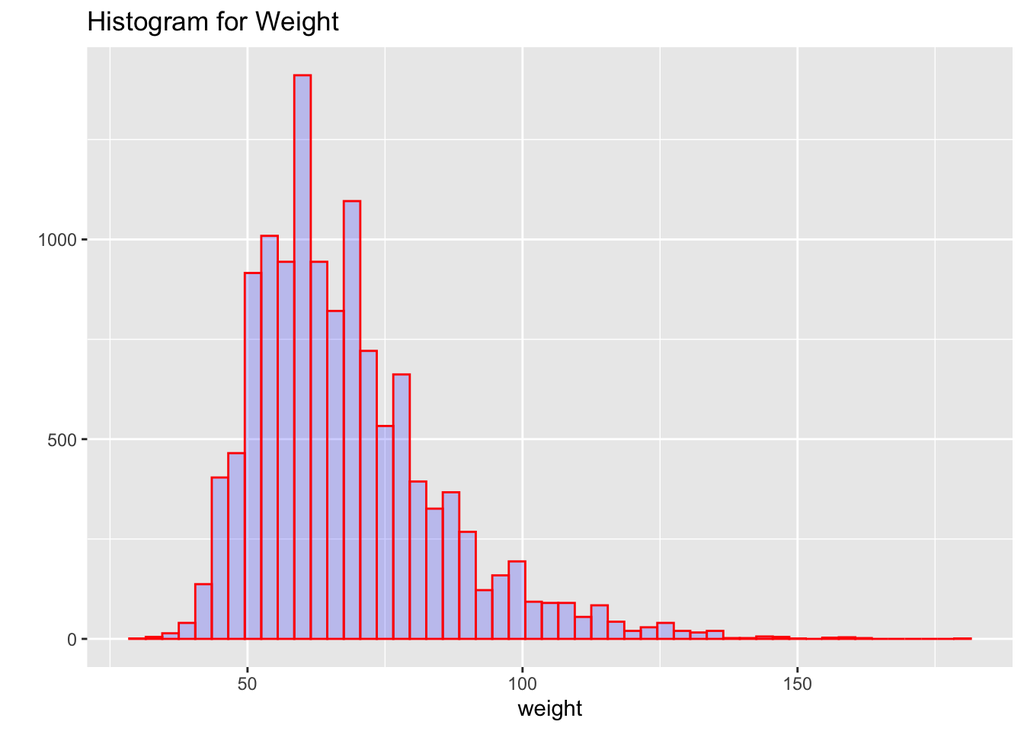

```r
qplot(yrbss$weight,
      geom="histogram",
      binwidth = 3,
      main = "Histogram for Weight",
      xlab = "weight",
      fill=I("blue"),
      col=I("red"),
      alpha=I(.2)
  )
```

2. How many observations are we missing weights from?
- **1004**

Next, consider the possible relationship between a high schooler’s weight and their physical activity. Plotting the data is a useful first step because it helps us quickly visualize trends, identify strong associations, and develop research questions.

First, let’s create a new variable `physical_3plus`, which will be coded as either “yes” if they are physically active for at least 3 days a week, and “no” if not.

```r
yrbss <- yrbss %>%
  mutate(physical_3plus = ifelse(yrbss$physically_active_7d > 2, "yes", "no"))
```

3. Make a side-by-side boxplot of `physical_3plus` and `weight`. Is there a relationship between these two variables? What did you expect and why?

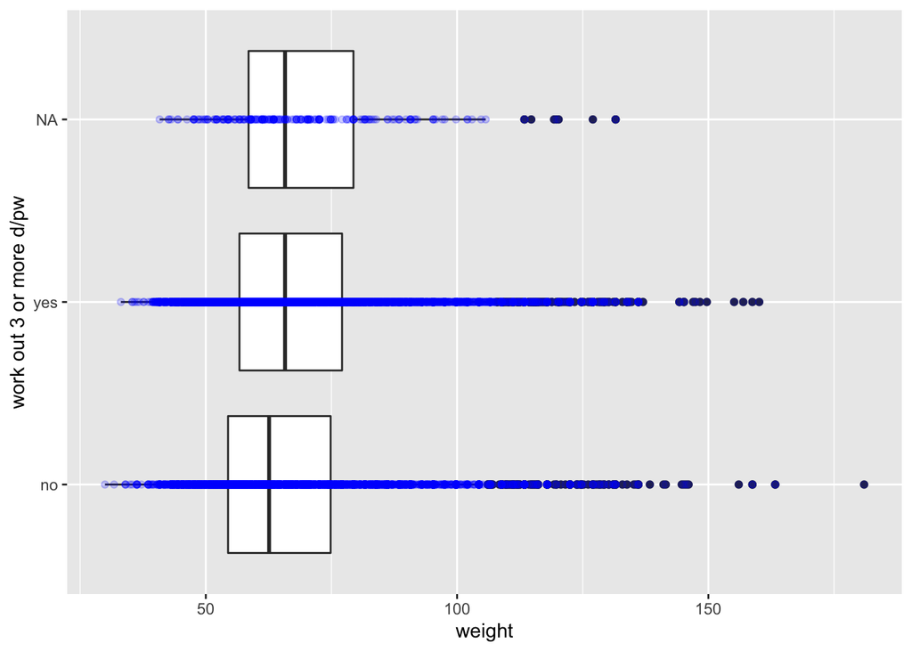

```r
ggplot(yrbss, aes(x=weight, y=physical_3plus)) +
  geom_boxplot() +
  geom_point(alpha=0.2, color='blue') +
  xlab('weight') +
  ylab('work out 3 or more d/pw')
```

The box plots show how the medians of the two distributions compare, but we can also compare the means of the distributions using the following to first group the data by the `physical_3plus` variable, and then calculate the mean `weight` in these groups using the `mean` function while ignoring missing values by setting the `na.rm` argument to `TRUE`.

```r
yrbss %>%
  group_by(physical_3plus) %>%
  summarise(mean_weight = mean(weight, na.rm = TRUE))
```

```
## # A tibble: 3 × 2
##   physical_3plus mean_weight
##   <chr>                <dbl>
## 1 no                    66.7
## 2 yes                   68.4
## 3 <NA>                  69.9
```

There is an observed difference, but is this difference statistically significant? In order to answer this question we will conduct a hypothesis test.

## Inference

4. Are all conditions necessary for inference satisfied? Comment on each. You can compute the group sizes with the `summarize` command above by defining a new variable with the definition `n()`.
- **Independence within groups - each case is for an individual student so we can assume that each case is independent**
- **Independence between groups - the independent variables**
- **Sample size/skew - the sample sizes are > 30 and the histogram for weight is near normal**

```r
yrbss %>%
  group_by(physical_3plus) %>%
  summarise(n = n())
```

```
## # A tibble: 3 × 2
##   physical_3plus     n
##   <chr>          <int>
## 1 no              4404
## 2 yes             8906
## 3 <NA>             273
```

5. Write the hypotheses for testing if the average weights are different for those who exercise at least times a week and those who don’t.
- **H0 - the average weights of students who work out 3 or more times a week is equal to the average weight for students who work out less than 3 times a week**
- **H1 - the average weights of students who work out 3 or more times a week is not equal to the a average weight for students who work out less than 3 times a week**

Next, we will introduce a new function, `hypothesize`, that falls into the `infer` workflow. You will use this method for conducting hypothesis tests.

But first, we need to initialize the test, which we will save as `obs_diff`.

```r
obs_diff <- yrbss %>%
  specify(weight ~ physical_3plus) %>%
  calculate(stat = "diff in means", order = c("yes", "no"))
```

Notice how you can use the functions `specify` and `calculate` again like you did for calculating confidence intervals. Here, though, the statistic you are searching for is the difference in means, with the order being `yes - no != 0`.

After you have initialized the test, you need to simulate the test on the null distribution, which we will save as `null`.

```r
null_dist <- yrbss %>%
  specify(weight ~ physical_3plus) %>%
  hypothesize(null = "independence") %>%
  generate(reps = 1000, type = "permute") %>%
  calculate(stat = "diff in means", order = c("yes", "no"))
```

Here, `hypothesize` is used to set the null hypothesis as a test for independence. In one sample cases, the `null` argument can be set to “point” to test a hypothesis relative to a point estimate.

Also, note that the `type` argument within `generate` is set to `permute`, whichis the argument when generating a null distribution for a hypothesis test.

We can visualize this null distribution with the following code:

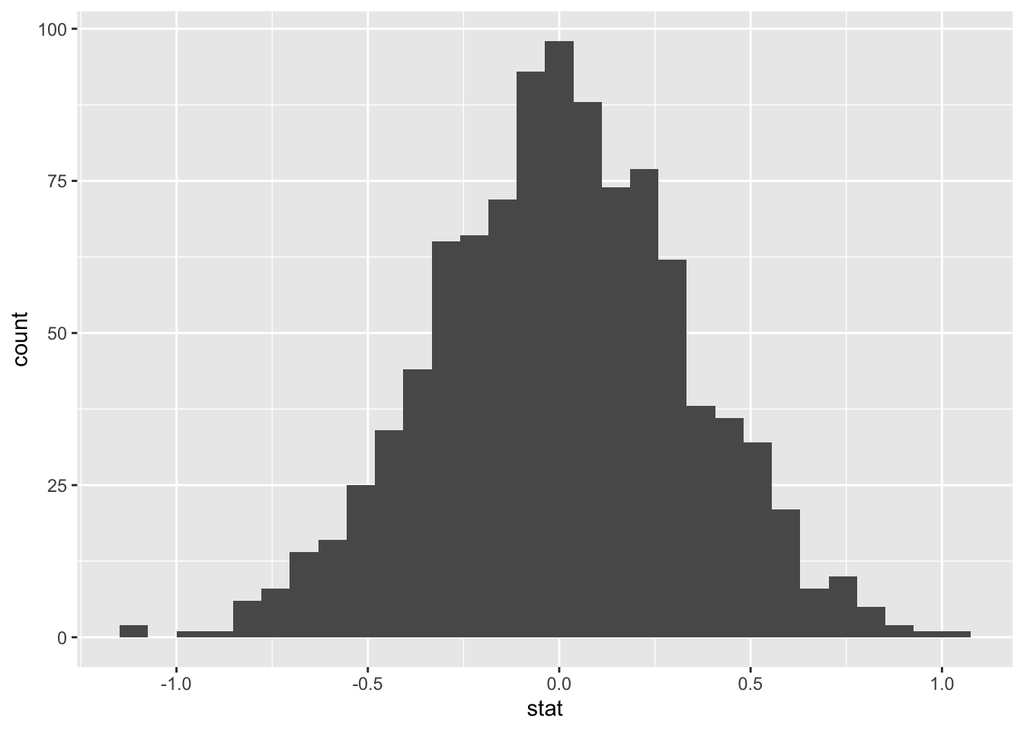

```r
ggplot(data = null_dist, aes(x = stat)) +
  geom_histogram()
```

6. How many of these `null` permutations have a difference of at least `obs_stat`?
- **0 - none**

```r
null_dist %>%
  mutate(diff_abs = abs(stat)) %>%
  filter(obs_diff$stat < diff_abs)
```

```
## Response: weight (numeric)
## Explanatory: physical_3plus (factor)
## Null Hypothesis: independence
## # A tibble: 0 × 3
## # … with 3 variables: replicate <int>, stat <dbl>, diff_abs <dbl>
```

```r
summary(null_dist)
```

```
##    replicate           stat
##  Min.   :   1.0   Min.   :-1.145660
##  1st Qu.: 250.8   1st Qu.:-0.222776
##  Median : 500.5   Median :-0.004444
##  Mean   : 500.5   Mean   : 0.002432
##  3rd Qu.: 750.2   3rd Qu.: 0.227438
##  Max.   :1000.0   Max.   : 1.002531
```

Now that the test is initialized and the null distribution formed, you can calculate the p-value for your hypothesis test using the function `get_p_value`.

```r
null_dist %>%
  get_p_value(obs_stat = obs_diff, direction = "two_sided")
```

```
## # A tibble: 1 × 1
##   p_value
##     <dbl>
## 1       0
```

This the standard workflow for performing hypothesis tests.

7. Construct and record a confidence interval for the difference between the weights of those who exercise at least three times a week and those who don’t, and interpret this interval in context of the data.

```r
y1_df <- yrbss %>% filter(physical_3plus == "yes" ) %>% drop_na(weight)
y2_df <- yrbss %>% filter(physical_3plus == "no" )  %>% drop_na(weight)


s1 <- sd(y1_df$weight)
n1 <- count(y1_df)$n
x1 <- mean(y1_df$weight)

s2 <- sd(y2_df$weight)
n2 <- count(y2_df)$n
x2 <- mean(y2_df$weight)

df <- min(n1-1, n2-1)
SE <- sqrt(s1^2/n1 + s2^2/n2)
PE <- x1 - x2


(CI <- c(PE-1.96*SE ,PE+1.96*SE))
```

```
## [1] 1.124821 2.424348
```

## More Practice

```r
h_df <- yrbss %>% drop_na(height)

s <- sd(h_df$height)
n <- count(h_df)$n
x <- mean(h_df$height)

SE <- s / sqrt(n)
PE <- x



z <- round(-qnorm((1-.90)/2),2)
(CI <- c(PE-z*SE ,PE+z*SE))
```

```
## [1] 1.689710 1.692772
```

9. Calculate a new confidence interval for the same parameter at the 90% confidence level. Comment on the width of this interval versus the one obtained in the previous exercise.

```r
z <- round(-qnorm((1-.90)/2),2)
(CI <- c(PE-z*SE ,PE+z*SE))
```

```
## [1] 1.689710 1.692772
```

10. Conduct a hypothesis test evaluating whether the average height is different for those who exercise at least three times a week and those who don’t.
- **H0 - There is no difference in the average heights for students who exercise 3 or more days a week and those who do not**
- **H1 - There is a difference in the average heights for students who exercise 3 or more days a week and those who do not**

```r
obs_diff <- yrbss %>%
  specify(height ~ physical_3plus) %>%
  calculate(stat = "diff in means", order = c("yes", "no"))


null_dist <- yrbss %>%
  specify(height ~ physical_3plus) %>%
  hypothesize(null = "independence") %>%
  generate(reps = 1000, type = "permute") %>%
  calculate(stat = "diff in means", order = c("yes", "no"))


null_dist %>% get_p_value(obs_stat = obs_diff, direction = "two_sided")
```

```
## # A tibble: 1 × 1
##   p_value
##     <dbl>
## 1       0
```

```r
null_dist %>% get_ci(level = 0.95, point_estimate = obs_diff )
```

```
## # A tibble: 1 × 2
##   lower_ci upper_ci
##      <dbl>    <dbl>
## 1 -0.00390  0.00389
```

- **with a p value of 0 we will reject the null hypothesis in favor of the alternative hypothesis at a 0.05 significance**
11. Now, a non-inference task: Determine the number of different options there are in the dataset for the `hours_tv_per_school_day` there are.

```r
yrbss %>% select(hours_tv_per_school_day) %>% distinct() %>% summarize(n())
```

```
## # A tibble: 1 × 1
##   `n()`
##   <int>
## 1     8
```

- **7 different options and NA for invalid obserations**
12. Come up with a research question evaluating the relationship between height or weight and sleep. Formulate the question in a way that it can be answered using a hypothesis test and/or a confidence interval. Report the statistical results, and also provide an explanation in plain language. Be sure to check all assumptions, state your $\alpha$ level, and conclude in context.

-**H0 - There is no difference in weight for those who are over 1.73 meters and those who are under** -**H1 - There is a difference in weight for those who are over 1.73 meters and those who are under**

**Conditions**

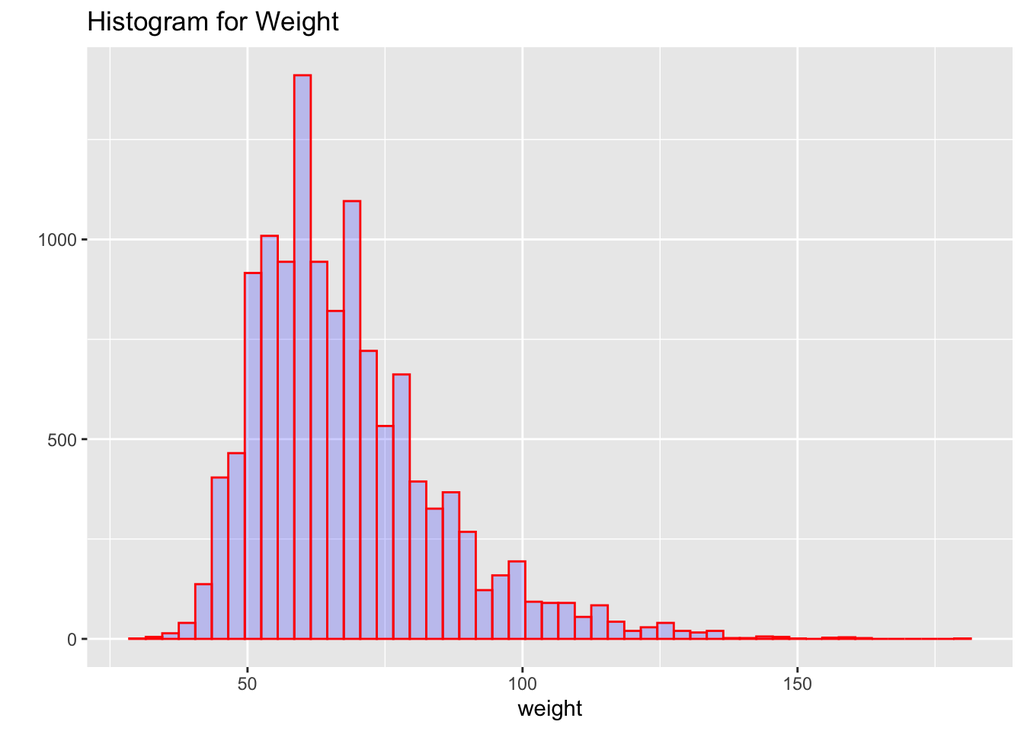

```r
qplot(yrbss$weight,
      geom="histogram",
      binwidth = 3,
      main = "Histogram for Weight",
      xlab = "weight",
      fill=I("blue"),
      col=I("red"),
      alpha=I(.2)
  )
```

```r
yrbss <- yrbss %>%
  mutate( height1.73 = ifelse(height >= 1.73, "yes", "no"))

obs_diff <- yrbss %>%
  specify(weight ~ height1.73) %>%
  calculate(stat = "diff in means", order = c("yes", "no"))


null_dist <- yrbss %>%
  specify(weight ~ physical_3plus) %>%
  hypothesize(null = "independence") %>%
  generate(reps = 1000, type = "permute") %>%
  calculate(stat = "diff in means", order = c("yes", "no"))


null_dist %>% get_p_value(obs_stat = obs_diff, direction = "two_sided")
```

```
## # A tibble: 1 × 1
##   p_value
##     <dbl>
## 1       0
```

```r
null_dist %>% get_ci(level = 0.95, point_estimate = obs_diff )
```

```
## # A tibble: 1 × 2
##   lower_ci upper_ci
##      <dbl>    <dbl>
## 1   -0.625    0.683
```

- **With a p value of 0 we will reject the null hypothesis in favor of the alternate hypothesis at the 0.05 significance level**